# Preparo

DQA

Maio, 21 2022

# Análise

## Quantidade de tentativas de ingresso

A tabela abaixo evidencia uma questão importante para a análise dos dados que refere-se à quantidade de vezes que os estudantes repetem o vestibular com vistas à bolsa de estudos. Importante ressaltar que os preços do vestibular quando comparados com o valor da mensalidade devem ser analisados.

| Processos | Percentual_repetem |
| --- | --- |
| 1 | 0.7203 |
| 2 | 0.2146 |
| 3 | 0.0474 |
| 4 | 0.0136 |
| 5 | 0.0031 |
| 6 | 0.0009 |
| 8 | 0.0001 |

Ainda é importante destacar que os dados provenientes da secretaria demandam uma remodelagem, por exemplo, com foco na identificação desses estudantes que repetem o processo.

## Notas vestibular por ingresso.

A tabela abaixo apresenta a média do CR obtida pelo estudante que no período ingressou pelo ENEM versus a média do CR do estudante que ingressou pelo vestibular.

| Processo | Média_CR |
| --- | --- |
| ENEM | 8.5 |
| VESTIBULAR | 8.07 |

Assim como na tabela anterior essa tabela evidencia os CR obtidos pelos estudantes a partir do ingresso em cada semestre considerado.

| Processo | 1801 | 1802 | 1901 | 1902 | 2001 | 2002 | 2101 | 2102 |
| --- | --- | --- | --- | --- | --- | --- | --- | --- |
| ENEM | 8.52 | 8.3 | 8.35 | 8.34 | 8.58 | 8.64 | 8.64 | 8.46 |
| VESTIBULAR | 8.04 | 7.75 | 8.01 | 7.84 | 8.22 | 8.13 | 8.21 | 7.87 |

A tabela abaixo evidencia o quantitativo de estudantes considerado em cada análise. Em particular, o quantitativo de estudantes de 2018 parece estar subavaliado.

| Processo | 1801 | 1802 | 1901 | 1902 | 2001 | 2002 | 2101 | 2102 |
| --- | --- | --- | --- | --- | --- | --- | --- | --- |
| ENEM | 114 | 136 | 475 | 387 | 709 | 504 | 605 | 326 |
| VESTIBULAR | 890 | 682 | 2408 | 1393 | 2995 | 1467 | 3188 | 1083 |

## Notas vest

A tabela a seguir apresenta a nota máxima e a nota mínima de cada área do conhecimento cadastrada no sistema de Notas do Vestibular.

| materia | Processo | Mínimo | Máximo |
| --- | --- | --- | --- |
| ENTREVISTA - GRADUAÇÃO | VESTIBULAR GRADUAÇÃO 2020/2 - POA | 0 | 8.6 |
| ENTREVISTA - GRADUAÇÃO | VESTIBULAR GRADUAÇÃO 2020/2 - RJ | 0 | 10 |
| ENTREVISTA - GRADUAÇÃO | VESTIBULAR GRADUAÇÃO 2020/2 - SP | 0 | 10 |
| ENTREVISTA - GRADUAÇÃO | VESTIBULAR GRADUAÇÃO 2021/1 - POA | 3 | 10 |
| ENTREVISTA - GRADUAÇÃO | VESTIBULAR GRADUAÇÃO 2021/1 - RJ | 0 | 10 |
| ENTREVISTA - GRADUAÇÃO | VESTIBULAR GRADUAÇÃO 2021/1 - SP | 0 | 10 |
| ENTREVISTA - GRADUAÇÃO | VESTIBULAR GRADUAÇÃO 2021/2 - POA | 7 | 10 |
| ENTREVISTA - GRADUAÇÃO | VESTIBULAR GRADUAÇÃO 2021/2 - RJ | 0 | 10 |
| ENTREVISTA - GRADUAÇÃO | VESTIBULAR GRADUAÇÃO 2021/2 - SP | 0 | 10 |
| ENTREVISTA - GRADUAÇÃO | VESTIBULAR GRADUAÇÃO 2022/1 - POA | 6.3 | 10 |

[output cut: 74 more lines]

### Notas VERÃO

A tabela a seguir apresenta a média em cada área do conhecimento nos vestibulares do Verão.

| Pln Acadêmico | ENTREVISTA - GRADUAÇÃO | HUMANIDADES E CULTURA GERAL CONTEMPORÂNEA | INGLÊS | MATEMATICA | PORTUGUES | REDAÇÃO - GRADUAÇÃO |
| --- | --- | --- | --- | --- | --- | --- |
| GADMSRJ | 8.19 | 12.46 | 4.37 | 5.81 | 9.19 | 4.82 |
| GADMSSP | 7.04 | 12.8 | 4.93 | 6.2 | 8.12 | 6.38 |
| GADMSSUL | 9.23 | 10.9 | 4.1 | 6.76 | 7.86 | 6.62 |
| GCINERJ | 8.1 | 12.71 | 5.14 | 5.6 | 9.04 | 4.93 |
| GCINESP | 7.47 | 14.04 | 5.76 | 6.21 | 9.85 | 6.73 |
| GCISOSP | 8.1 | 13.41 | 5.17 | 5.61 | 9.11 | 6.32 |
| GCSOSRJ | 7.97 | 12.59 | 5.09 | 5.72 | 8.93 | 5.07 |
| GCSOSSP | 8.28 | 14.52 | 5.99 | 6.44 | 10.45 | 6.71 |
| GCSOSSUL | 7.73 | 11.89 | 5 | 5.21 | 9.61 | 7.12 |
| GDESGRJ | 7.03 | 12.43 | 6.01 | 5.69 | 8.78 | 4.89 |

[output cut: 9 more lines]

### Notas INVERNO

A tabela a seguir apresenta a média em cada área do conhecimento nos vestibulares de inverno.

| Pln Acadêmico | ENTREVISTA - GRADUAÇÃO | HUMANIDADES E CULTURA GERAL CONTEMPORÂNEA | INGLÊS | MATEMATICA | PORTUGUES | REDAÇÃO - GRADUAÇÃO |
| --- | --- | --- | --- | --- | --- | --- |
| GADMSRJ | 7.76 | 12.24 | 5.28 | 5.52 | 8.79 | 4.99 |
| GADMSSP | 7.07 | 12.8 | 5.02 | 6.05 | 8.59 | 6.41 |
| GADMSSUL | 4.6 | 11 | 2 | 5 | 6 | 7 |
| GCINERJ | 8.44 | 13.43 | 4.93 | 5.19 | 8.81 | 5.41 |
| GCINESP | 7.41 | 14.47 | 6.2 | 6.29 | 10.49 | 6.54 |
| GCISOSP | 7.99 | 12.74 | 5.03 | 4.95 | 9.15 | 6.38 |
| GCSOSRJ | 8.07 | 11.96 | 4.84 | 5.32 | 9.42 | 5.14 |
| GCSOSSP | 7.8 | 13.02 | 4.89 | 5.33 | 9.54 | 6.38 |
| GCSOSSUL | 8.29 | 11.43 | 3.29 | 5.43 | 9.14 | 6.91 |
| GDESGRJ | 7.75 | 12.48 | 5.83 | 5.29 | 9.67 | 4.97 |

[output cut: 9 more lines]

# Análise dos TALENTOS

## Comparativo entre o CR dos talentos e dos demais estudantes.

| Admissão | Talentos_CR | Demais_CR |
| --- | --- | --- |
| 1801 | 7.92 | 8.04 |
| 1802 | 8.13 | 7.79 |
| 1901 | 8.19 | 8.01 |
| 1902 | 8.49 | 7.91 |
| 2001 | 8.85 | 8.21 |
| 2002 | 8.4 | 8.22 |
| 2101 | 8.74 | 8.23 |
| 2102 | 8.58 | 8.03 |

### Curso escolhido pelos Talentos

A tabela abaixo evidencia o curso escolhido pelos talentos para ingresso.

| Pln Acadêmico | 1801 | 1802 | 1901 | 1902 | 2001 | 2002 | 2101 | 2102 |
| --- | --- | --- | --- | --- | --- | --- | --- | --- |
| GADMSRJ | 1 | 3 | 5 | 1 | 1 | 10 | NA | NA |
| GADMSSP | 55 | 31 | 44 | 12 | 9 | 10 | 8 | 2 |
| GCISOSP | 7 | 21 | 11 | 8 | 6 | NA | 9 | 6 |
| GCSOSRJ | 1 | NA | 9 | 2 | 16 | 4 | 15 | 4 |
| GCSOSSP | 86 | 86 | 224 | 61 | 56 | 54 | 70 | 85 |
| GDESGRJ | 3 | 3 | 3 | 1 | 2 | 15 | 1 | NA |
| GDESGSP | 16 | 39 | 25 | 22 | 17 | 16 | 12 | 1 |
| GJORNRJ | 2 | 1 | 7 | 4 | 9 | 3 | 2 | 2 |
| GJORNSP | 5 | 8 | 15 | 7 | 3 | 3 | 4 | NA |
| GRINTSP | 17 | 29 | 24 | 28 | 15 | 28 | 15 | 7 |

[output cut: 9 more lines]

## Análise do Status dos estudantes

A tabela abaixo visa evidenciar se qual o status dos estudantes, em particular dos talentos.

| Status | Descrição | Status_Talentos | Status_Demais |
| --- | --- | --- | --- |
| Ativo | Possível Concluinte | 0.0028116213683224 | 0.00112666560210074 |
| Ativo | NA | 0.44095595126523 | 0.325544259328259 |
| Concluído | NA | 0.0674789128397376 | 0.0342346658150139 |
| Dispensado | Alteraçao Opção Curso Ingresso | 0.000468603561387067 | 0.00124199357711893 |
| Dispensado | Alteração opção curso ingresso | 0.0192127460168697 | 0.0165273859583755 |
| Dispensado | Bolsa Inst não concedida | 0.0028116213683224 | 0.000337112542360852 |
| Dispensado | Bolsa Inst. não concedida | 0.0028116213683224 | 0.00203154663685882 |
| Dispensado | Conclusão GREMANESC_WAE | 0.00328022492970947 | 0.00134845016944341 |
| Dispensado | Curso no exterior | 0.00609184629803187 | 0.00241301609268821 |
| Dispensado | Financeiro | 0.0178069353327085 | 0.0120207235499725 |

[output cut: 24 more lines]

Abaixo destacamos o quantitativo de estudantes o percentual dos estudantes que não confirmaram a matrícula.

| Status_Talentos | Status_Demais |
| --- | --- |
| 0.213683223992502 | 0.421160022001029 |

### Análise da situação de não confirmação.

| Plano | 1802 | 1901 | 1902 | 2001 | 2002 | 2101 | 2102 |
| --- | --- | --- | --- | --- | --- | --- | --- |
| GADMSRJ | 0.08 | 0.552529182879377 | 0.570588235294118 | 0.511551155115512 | 0.40952380952381 | 0.468085106382979 | 0.53448275862069 |
| GADMSSP | NA | 0.517105780574125 | 0.455064194008559 | 0.473312748125276 | 0.464285714285714 | 0.433526011560694 | 0.465181058495822 |
| GADMSSUL | NA | 0.36734693877551 | NA | 0.490909090909091 | 0.833333333333333 | 0.388888888888889 | 0.9 |
| GCINERJ | NA | 0.524590163934426 | 0.454545454545455 | 0.518279569892473 | 0.6 | 0.48314606741573 | 0.526315789473684 |
| GCINESP | NA | 0.536891679748823 | 0.384039900249377 | 0.646464646464647 | 0.46875 | 0.536977491961415 | 0.521008403361345 |
| GCISOSP | NA | 0.556782334384858 | 0.331932773109244 | 0.486146095717884 | 0.402985074626866 | 0.364779874213836 | 0.26530612244898 |
| GCSOSRJ | 0.0133779264214047 | 0.429731925264013 | 0.507246376811594 | 0.445709281961471 | 0.64957264957265 | 0.501766784452297 | 0.514767932489452 |
| GCSOSSP | 0.0152380952380952 | 0.277178423236515 | 0.386378737541528 | 0.291605839416058 | 0.308405029781602 | 0.377296587926509 | 0.44945567651633 |
| GCSOSSUL | NA | 0.614754098360656 | 0.25 | 0.534090909090909 | 0.333333333333333 | 0.622641509433962 | 0.384615384615385 |
| GDESGRJ | 0.0508474576271186 | 0.4275 | 0.417808219178082 | 0.414507772020725 | 0.606837606837607 | 0.45625 | 0.281818181818182 |

[output cut: 9 more lines]

## Correlação entre nota e posição

```
## 'data.frame':    5563 obs. of  3 variables:
##  $ Classificação: int  313 126 607 343 245 291 491 177 68 700 ...
##  $ total        : chr  "0,00" "0,00" "32,00" "0,00" ...
##  $ CR           : num  8.03 8.76 8.41 9.07 8.54 ...
```

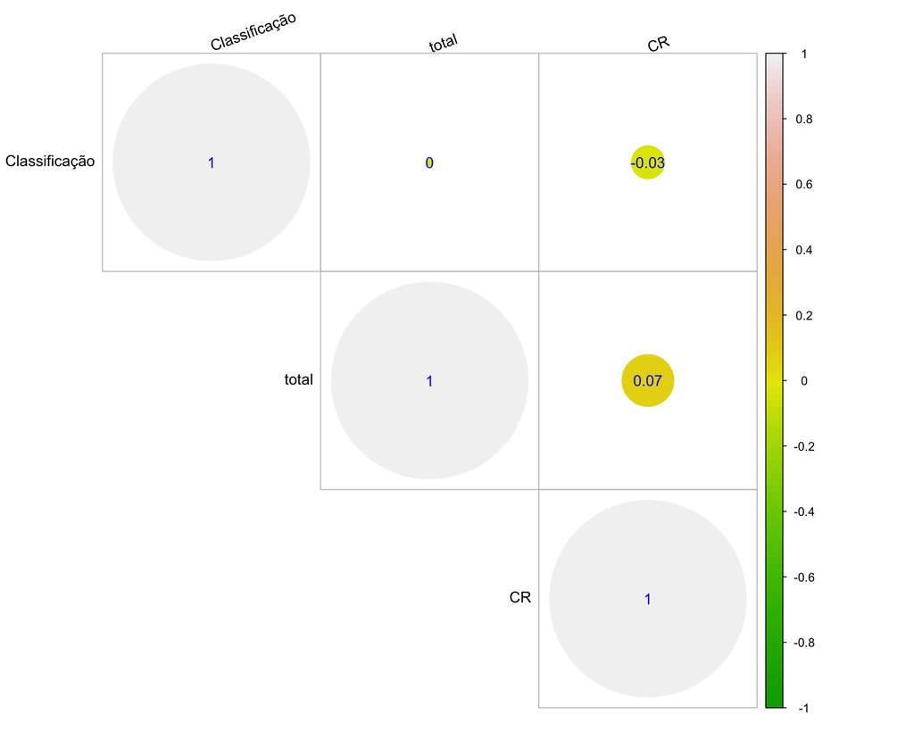